# 資管新生專題 銷售預測 平衡墊

Jack Chen

2019/12/21

#### (零)

載入資料

```r
library(readxl)
data1 <- read_excel("final.xlsx",skip = 1,sheet = 1)
data2 <- read_excel("final.xlsx",skip = 1,sheet = 2)
data3 <- read_excel("final.xlsx",skip = 1,sheet = 3)
data4 <- read_excel("final.xlsx",skip = 1,sheet = 4)
```

#### (一)

只用**價格+累積評論+累積星等**(自己公司&競爭公司)當作自變數

```r
regressor1 <- lm(Q~P+S+C+P2+S2+C2+P3+S3+C3+P4+S4+C4+P5+S5+C5+W,data = data1)
#summary(regressor1)
```

**Adjusted R-squared=0.6541**

#### (二)

刪除**累積評論**、**還未開始銷售**之資料

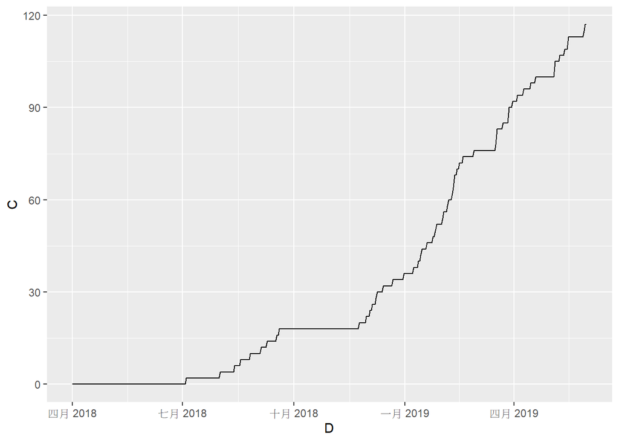

```r
library(ggplot2)
ggplot(data1,aes(x = D,y = C))+
  geom_line(na.rm = TRUE)
```

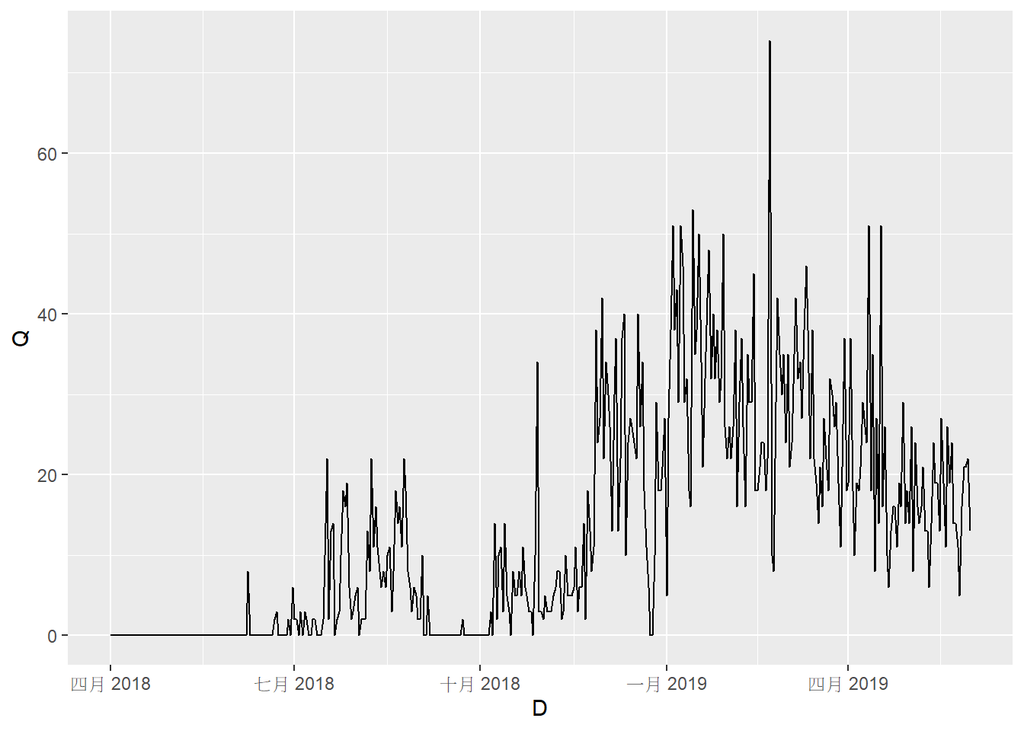

```r
ggplot(data1,aes(x = D,y = Q))+
  geom_line(na.rm = TRUE)
```

```r
regressor1.5 <- lm(Q~P+S+P2+S2+P3+S3+P4+S4+P5+S5,data = data2)
#summary(regressor1.5)
```

**Adjusted R-squared=0.4237**

#### (三)

加上**時間序列**的影響  
製造出**七天、三十天、九十天**三個時間區段的評價數與星等  
以及該日**是否周末**，是的給1、不是給0  
一共41個自變數

```r
regressor2 <- lm(Q~P+S+SC+TC+NC+SS+TS+NS+
                P2+S2+SC2+TC2+NC2+SS2+TS2+NS2+
                P3+S3+SC3+TC3+NC3+SS3+TS3+NS3+
                P4+S4+SC4+TC4+NC4+SS4+TS4+NS4+
                P5+S5+SC5+TC5+NC5+SS5+TS5+NS5+W,data = data2)
summary(regressor2)
```

```
##
## Call:
## lm(formula = Q ~ P + S + SC + TC + NC + SS + TS + NS + P2 + S2 +
##     SC2 + TC2 + NC2 + SS2 + TS2 + NS2 + P3 + S3 + SC3 + TC3 +
##     NC3 + SS3 + TS3 + NS3 + P4 + S4 + SC4 + TC4 + NC4 + SS4 +
##     TS4 + NS4 + P5 + S5 + SC5 + TC5 + NC5 + SS5 + TS5 + NS5 +
##     W, data = data2)
##
## Residuals:
##     Min      1Q  Median      3Q     Max
## -22.700  -4.448  -0.681   3.650  44.133
##
## Coefficients:
##              Estimate Std. Error t value Pr(>|t|)
## (Intercept)  44.38241  174.96901   0.254 0.799939
## P            -1.01690    0.63123  -1.611 0.108270
## S           -11.00033   17.88398  -0.615 0.538975
## SC            0.12866    0.35791   0.359 0.719493
## TC           -0.43185    0.22756  -1.898 0.058729 .
## NC           -0.17870    0.19154  -0.933 0.351606
## SS           -0.44397    0.39901  -1.113 0.266769
## TS            0.44170    0.69149   0.639 0.523477
## NS           -0.40144    2.25589  -0.178 0.858885
## P2           -0.13730    0.08454  -1.624 0.105426
## S2            3.43590   20.34156   0.169 0.865985
## SC2           1.87228    1.21391   1.542 0.124079
## TC2          -0.13473    0.75439  -0.179 0.858376
## NC2          -0.37571    0.59882  -0.627 0.530872
## SS2          -0.53457    0.37889  -1.411 0.159346
## TS2          -1.42749    0.75525  -1.890 0.059742 .
## NS2           2.86673    5.44981   0.526 0.599274
## P3            0.65353    1.78249   0.367 0.714155
## S3           30.43833   15.18089   2.005 0.045888 *
## SC3           0.31027    0.40818   0.760 0.447796
## TC3           0.43080    0.30261   1.424 0.155634
## NC3          -0.05021    0.22458  -0.224 0.823259
## SS3          -0.48415    0.36245  -1.336 0.182665
## TS3           3.08409    2.21024   1.395 0.163973
## NS3         -29.43577    8.11542  -3.627 0.000338 ***
## P4            1.97316    2.31111   0.854 0.393936
## S4           -3.17563    6.29330  -0.505 0.614219
## SC4          -0.43719    1.43841  -0.304 0.761390
## TC4           0.60591    0.80518   0.753 0.452354
## NC4           0.19972    0.83664   0.239 0.811497
## SS4           0.11224    0.48941   0.229 0.818765
## TS4           0.22443    0.51151   0.439 0.661160
## NS4          -1.87876    0.93407  -2.011 0.045212 *
## P5            1.47356    0.76678   1.922 0.055618 .
## S5          -28.37232   23.67558  -1.198 0.231748
## SC5          -2.13645    1.14968  -1.858 0.064140 .
## TC5           2.79333    0.82765   3.375 0.000839 ***
## NC5           1.10678    0.76256   1.451 0.147748
## SS5          -0.11466    0.37485  -0.306 0.759910
## TS5           1.87677    3.26314   0.575 0.565641
## NS5          16.90066    7.77008   2.175 0.030431 *
## W            -3.67764    1.04728  -3.512 0.000516 ***
## ---
## Signif. codes:  0 '***' 0.001 '**' 0.01 '*' 0.05 '.' 0.1 ' ' 1
##
## Residual standard error: 8.313 on 290 degrees of freedom
## Multiple R-squared:  0.6776, Adjusted R-squared:  0.632
## F-statistic: 14.86 on 41 and 290 DF,  p-value: < 2.2e-16
```

**Adjusted R-squared=0.632**  
但變數過多，其中有許多較不相關之變數

#### (四)

刪除影響較小的變數  
透過T test產生的P-Value來決定

```r
regressor3 <- lm(Q~P+TC+NC+SS+
                P2+SC2+NC2+SS2+TS2+
                S3+TC3+SS3+TS3+NS3+
                TC4+NS4+
                P5+S5+SC5+TC5+NC5+NS5+W,data = data2)
summary(regressor3)
```

```
##
## Call:
## lm(formula = Q ~ P + TC + NC + SS + P2 + SC2 + NC2 + SS2 + TS2 +
##     S3 + TC3 + SS3 + TS3 + NS3 + TC4 + NS4 + P5 + S5 + SC5 +
##     TC5 + NC5 + NS5 + W, data = data2)
##
## Residuals:
##     Min      1Q  Median      3Q     Max
## -22.889  -4.489  -0.718   3.643  43.851
##
## Coefficients:
##              Estimate Std. Error t value Pr(>|t|)
## (Intercept) -50.81620   60.26909  -0.843 0.399796
## P            -0.79976    0.53561  -1.493 0.136415
## TC           -0.39688    0.16355  -2.427 0.015811 *
## NC           -0.08128    0.09861  -0.824 0.410392
## SS           -0.24829    0.26547  -0.935 0.350389
## P2           -0.14750    0.07080  -2.083 0.038039 *
## SC2           2.11100    1.00742   2.095 0.036948 *
## NC2          -0.43091    0.39757  -1.084 0.279270
## SS2          -0.63540    0.32870  -1.933 0.054146 .
## TS2          -1.70697    0.59825  -2.853 0.004620 **
## S3           44.59330   10.98565   4.059 6.25e-05 ***
## TC3           0.48980    0.15620   3.136 0.001880 **
## SS3          -0.47134    0.32689  -1.442 0.150345
## TS3           3.36643    1.84467   1.825 0.068977 .
## NS3         -33.45718    6.68719  -5.003 9.50e-07 ***
## TC4           0.98290    0.46129   2.131 0.033901 *
## NS4          -2.20022    0.62722  -3.508 0.000519 ***
## P5            1.46125    0.68650   2.129 0.034085 *
## S5          -19.56091   17.02963  -1.149 0.251596
## SC5          -2.35603    0.64191  -3.670 0.000285 ***
## TC5           2.50538    0.55559   4.509 9.25e-06 ***
## NC5           1.27007    0.37393   3.397 0.000772 ***
## NS5          19.64760    6.16261   3.188 0.001579 **
## W            -3.80006    1.00612  -3.777 0.000191 ***
## ---
## Signif. codes:  0 '***' 0.001 '**' 0.01 '*' 0.05 '.' 0.1 ' ' 1
##
## Residual standard error: 8.134 on 308 degrees of freedom
## Multiple R-squared:  0.6722, Adjusted R-squared:  0.6477
## F-statistic: 27.46 on 23 and 308 DF,  p-value: < 2.2e-16
```

**Adjusted R-squared=0.6477**  
也減少了不相干的變數

其中P3因起伏過小，故刪除

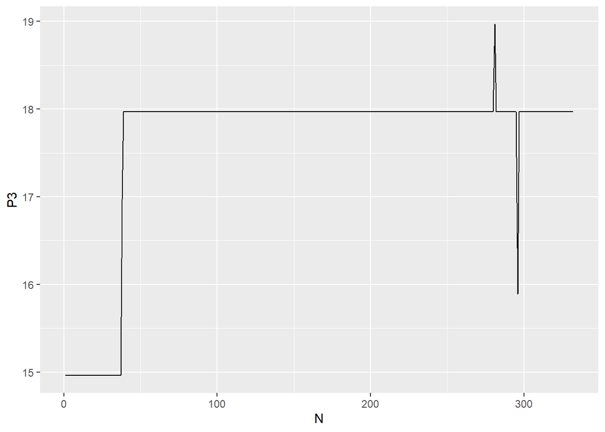

```r
ggplot(data2,aes(x = N,y = P3))+
  geom_line(na.rm = TRUE)
```

最後選用的自變數  
P+TC+NC+SS+  
P2+SC2+NC2+SS2+TS2+  
S3+TC3+SS3+TS3+NS3+  
TC4+NS4+  
P5+S5+SC5+TC5+NC5+NS5+W 共23個  
**Adjusted R-squared=0.6477**

#### (五)

以regressor3(Adjusted R-squared=0.6477)做**k-fold cross-validation**  
使用**R-squared**與**RMSE/mean(=Error Rate)**作為判斷指標

```r
library(plyr)
library(tidyverse)
library(caret)
```

```r
CVgroup <- function(k, datasize, seed) {
  cvlist <- list()
  set.seed(seed)
  n <- rep(1:k, ceiling(datasize/k))[1:datasize]
  #將資料分成K份，並生成的完整資料集n
  temp <- sample(n, datasize)  #把n打亂
  x <- 1:k
  dataseq <- 1:datasize
  cvlist <- lapply(x, function(x) dataseq[temp==x])
  #dataseq中隨機生成10個隨機有序資料列
  return(cvlist)
}
##################################################

#R-squared
CV_R <- function(list,data,cnt){

  data_train <- data[-list[[cnt]],]
  data_val <- data[list[[cnt]],]
  #split the data

  data_sub <- select(data_val,P,TC,NC,SS,P2,SC2,NC2,SS2,TS2,S3,TC3,SS3,TS3,NS3,TC4,NS4,P5,S5,SC5,TC5,NC5,NS5,W)
  R <- lm(Q~P+TC+NC+SS+P2+SC2+NC2+SS2+TS2+S3+TC3+SS3+TS3+NS3+TC4+NS4+P5+S5+SC5+TC5+NC5+NS5+W,data = data_train)
  #choose x

  Q_Pre <- predict(R,data_sub)
  Q_Real <- data_val[["Q"]]
  return(R2(Q_Pre,Q_Real))
}
##################################################

#Error Rate(RMSE / mean)
CV_ER <- function(list,data,cnt){

  data_train <- data[-list[[cnt]],]
  data_val <- data[list[[cnt]],]
  #split the data

  data_sub <- select(data_val,P,TC,NC,SS,P2,SC2,NC2,SS2,TS2,S3,TC3,SS3,TS3,NS3,TC4,NS4,P5,S5,SC5,TC5,NC5,NS5,W)
  R <- lm(Q~P+TC+NC+SS+P2+SC2+NC2+SS2+TS2+S3+TC3+SS3+TS3+NS3+TC4+NS4+P5+S5+SC5+TC5+NC5+NS5+W,data = data_train)
  #choose x

  Q_Pre <- predict(R,data_sub)
  Q_Real <- data_val[["Q"]]

  RSS <- sum((Q_Real - Q_Pre)^2)#SSE
  RMSE <- (RSS / (nrow(data_val))) ^ 0.5
  return(RMSE / mean(Q_Pre))
}
##################################################

#Result
cvlist <- CVgroup(10,datasize = nrow(data2),seed = 1221)

V <-vector("numeric",0)
print("R-squared : ")
for(i in 1:10){
  R <- CV_R(cvlist,data2,i)
  V <- c(V,R)
}
print(V)
print("Mean : ")
print(mean(V))
print("=================================")

V2 <- vector("numeric",0)
print("Error Rate : ")
for(i in 1:10){
  ER <- CV_ER(cvlist,data2,i)
  V2 <- c(V2,ER)
}
print(V2)
print("Mean : ")
print(mean(V2))
```

```
## [1] "R-squared : "
##  [1] 0.6903110 0.7400856 0.7910828 0.5128523 0.6281110 0.5502684 0.7127447
##  [8] 0.6619112 0.6783086 0.4433351
## [1] "Mean : "
## [1] 0.6409011
## [1] "================================="
## [1] "Error Rate : "
##  [1] 0.4559005 0.3511585 0.4079238 0.6545406 0.5202219 0.6194028 0.5356875
##  [8] 0.4660061 0.4239410 0.5597164
## [1] "Mean : "
## [1] 0.4994499
```

#### (六)

進行預測，並將結果寫入檔案與視覺化

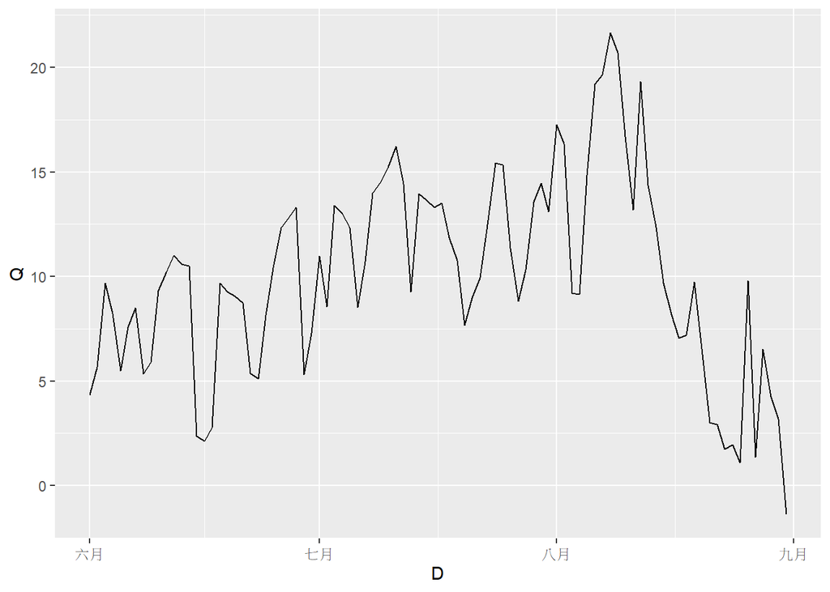

```r
Q_PRE <- predict(regressor3,data3)
data_Pre <- data.frame(Q = Q_PRE,D = data4[["D"]])
write_csv(data_Pre,"write.csv")
ggplot(data_Pre,aes(x = D,y = Q))+
  geom_line(na.rm = TRUE)
```